# kc_houseprice_analysis

### Map check

Visualize each zipcode area where the property prices have been underestamted by more than 20%  
And plot the property locations with price % difference less than 20% (more or less accurate estimate) in black  
And plot the property locations with price % difference more than 20% (inaccurate estimate) in red  
To estimate if there are specific location hubs where properties are more luxurious/ expensive and that model does not pick up

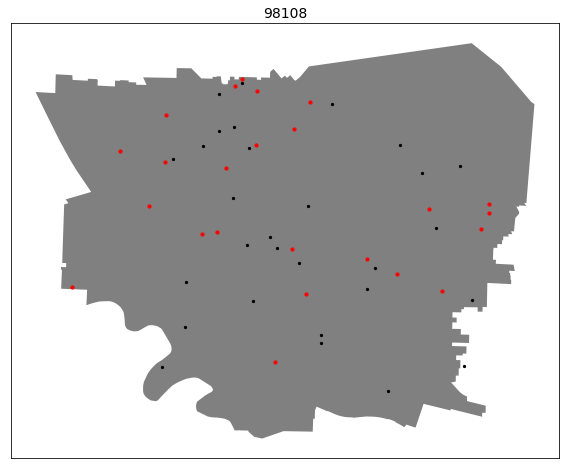

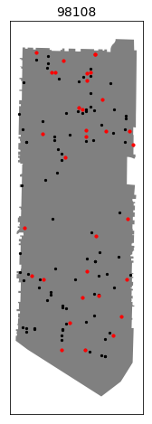

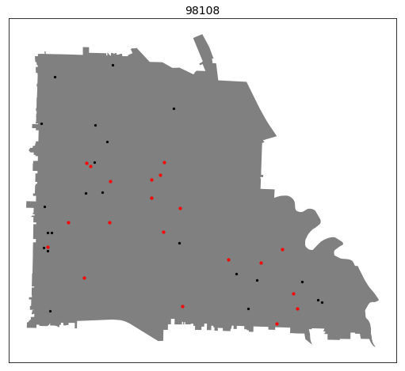

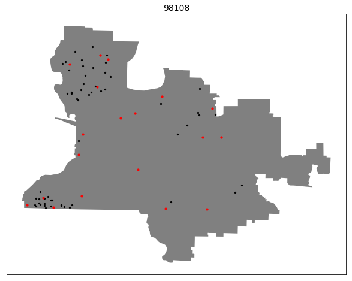

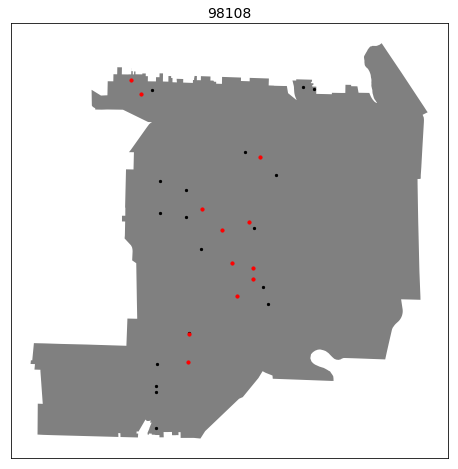

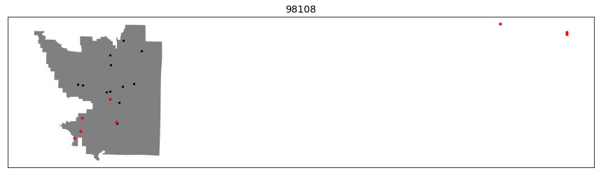

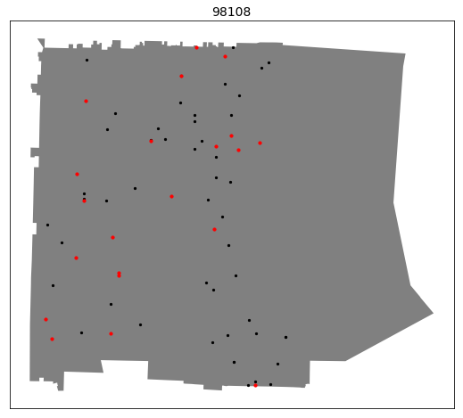

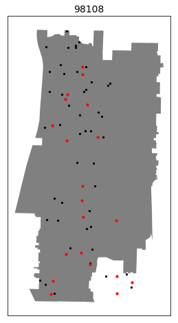

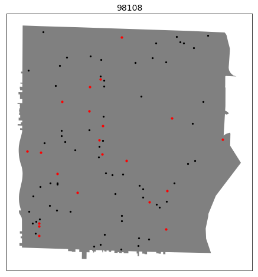

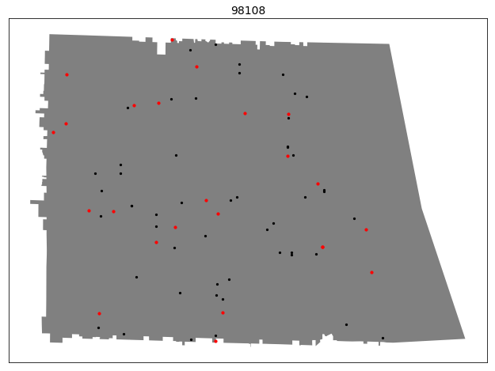

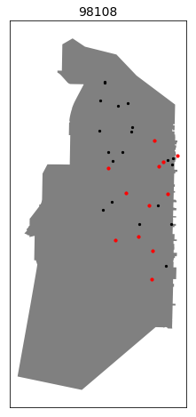

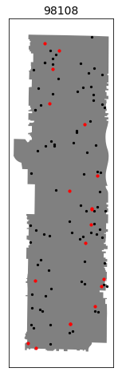

[11 more figures not shown]

```python
for i in range(len(zipcodes_with_highest_diff)):
    base = pred_analysis_gdf[pred_analysis_gdf.index == zipcodes_with_highest_diff[i]].plot(color = "grey", figsize=(15, 8), legend = True)
    temp_point = sale_points_gdf[sale_points_gdf["zipcode"] == zipcodes_with_highest_diff[i]]
    temp_point = temp_point.to_crs(zip_codes.crs)
    temp_point[abs(temp_point["diff_perc"]) < 0.2].plot(ax=base, marker = "o", color = "black", markersize=5)
    temp_point[abs(temp_point["diff_perc"]) > 0.2].plot(ax=base, marker = "o", color = "red", markersize=10)

    plt.xticks([])
    plt.yticks([])
    plt.title(zipcodes_with_highest_diff[0], fontsize = 14)
    plt.show()
```

### Comments

Many zipcode areas show the correctly estimated house prices are in close proximity to incorrectly estimated house prices  
However, in some cases, there are areas with red dots (inaccurately estimated house prices) that are away from other properties  
Since we can see that price per sqft depends on the location/ street/ area,  
It could be useful to divide the spacial locations into a finer grids, and use these grids as features

### Future ideas

1) Divide the spatial area into grids and treat each grid as a feature to achieve a finer spatial separation between properties